## Tie1 F2s

Quick analysis to determine if we should look at more F2s to distinguigh between GA2ox and the Alpha Glucosidase as causative for tie-1 phenotype

Get the data and take a quick look

```r
tie1 <- read.csv("tie.F2s.csv",na.strings=c("NA","-"))
summary(tie1)
```

```
##      plant        AG        GA2          flat            epi
##  1      : 1   heinz: 7   heinz:10   Min.   :1.000   Min.   :11.35
##  10     : 1   het  :27   het  :35   1st Qu.:2.000   1st Qu.:17.61
##  11     : 1   M82  :23   M82  :13   Median :5.000   Median :22.21
##  12     : 1   NA's : 2   NA's : 1   Mean   :4.441   Mean   :24.25
##  13     : 1                         3rd Qu.:6.000   3rd Qu.:30.60
##  14     : 1                         Max.   :8.000   Max.   :48.65
##  (Other):53                                         NA's   :1
##              X           int1                  X.1          int2
##  7/14/15 10:04: 2   Min.   : 6.93   7/14/15 10:04: 2   Min.   : 0.050
##  7/14/15 10:12: 2   1st Qu.:12.82   7/14/15 10:12: 2   1st Qu.: 7.003
##  7/14/15 10:14: 2   Median :15.63   7/14/15 9:09 : 2   Median : 9.005
##  7/14/15 9:09 : 2   Mean   :17.19   7/14/15 9:30 : 2   Mean   :11.078
##  7/14/15 9:29 : 2   3rd Qu.:18.26   7/14/15 9:49 : 2   3rd Qu.:12.010
##  7/14/15 9:36 : 2   Max.   :35.76   7/14/15 9:59 : 2   Max.   :33.100
##  (Other)      :47   NA's   :1       (Other)      :47   NA's   :1
##             X.2       first.leaf
##  7/14/15 10:05: 2   Min.   :1.000
##  7/14/15 10:08: 2   1st Qu.:1.000
##  7/14/15 10:11: 2   Median :1.000
##  7/14/15 10:12: 2   Mean   :1.138
##  7/14/15 10:33: 2   3rd Qu.:1.000
##  7/14/15 9:11 : 2   Max.   :2.000
##  (Other)      :47   NA's   :1
```

```r
head(tie1)
```

```
##   plant    AG   GA2 flat   epi             X  int1           X.1  int2
## 1     1   M82   het    1 17.55 7/14/15 10:31 16.12 7/14/15 10:31  1.46
## 2     2   het   het    1 22.11  7/14/15 9:09 16.45  7/14/15 9:09  7.54
## 3     3  <NA>   het    1 24.01  7/14/15 9:09 15.20  7/14/15 9:09  8.34
## 4     4   M82   M82    1 37.96  7/14/15 9:10 35.76  7/14/15 9:10 24.30
## 5     5 heinz heinz    1 11.91  7/14/15 9:11 12.63  7/14/15 9:11  7.68
## 6     6   M82   M82    1 32.01  7/14/15 9:12 30.11  7/14/15 9:12  9.39
##             X.2 first.leaf
## 1 7/14/15 10:31          2
## 2  7/14/15 9:09          1
## 3  7/14/15 9:10          1
## 4  7/14/15 9:11          1
## 5  7/14/15 9:11          1
## 6  7/14/15 9:12          1
```

```r
tie1$gt <- paste("GA2ox",tie1$GA2,"_AG.2",tie1$AG,sep="")
tie1$height <- tie1$epi + tie1$int1 + tie1$int2
tie1$int.total <- tie1$int1 + tie1$int2
```

Remove unused columns

```r
tie1.small <- tie1[,!grepl("X",colnames(tie1))]
#tie1.small <- tie1.small[tie1.small$first.leaf=="1",] #remove wierd plants where there are 2 leave at first node.
head(tie1.small)
```

```
##   plant    AG   GA2 flat   epi  int1  int2 first.leaf                   gt
## 1     1   M82   het    1 17.55 16.12  1.46          2     GA2oxhet_AG.2M82
## 2     2   het   het    1 22.11 16.45  7.54          1     GA2oxhet_AG.2het
## 3     3  <NA>   het    1 24.01 15.20  8.34          1      GA2oxhet_AG.2NA
## 4     4   M82   M82    1 37.96 35.76 24.30          1     GA2oxM82_AG.2M82
## 5     5 heinz heinz    1 11.91 12.63  7.68          1 GA2oxheinz_AG.2heinz
## 6     6   M82   M82    1 32.01 30.11  9.39          1     GA2oxM82_AG.2M82
##   height int.total
## 1  35.13     17.58
## 2  46.10     23.99
## 3  47.55     23.54
## 4  98.02     60.06
## 5  32.22     20.31
## 6  71.51     39.50
```

melt

```r
library(reshape2)
tie1.melt <- melt(tie1.small,id.vars = c("plant","GA2","AG","gt","flat","first.leaf"),variable.name="organ")
head(tie1.melt)
```

```
##   plant   GA2    AG                   gt flat first.leaf organ value
## 1     1   het   M82     GA2oxhet_AG.2M82    1          2   epi 17.55
## 2     2   het   het     GA2oxhet_AG.2het    1          1   epi 22.11
## 3     3   het  <NA>      GA2oxhet_AG.2NA    1          1   epi 24.01
## 4     4   M82   M82     GA2oxM82_AG.2M82    1          1   epi 37.96
## 5     5 heinz heinz GA2oxheinz_AG.2heinz    1          1   epi 11.91
## 6     6   M82   M82     GA2oxM82_AG.2M82    1          1   epi 32.01
```

plot it

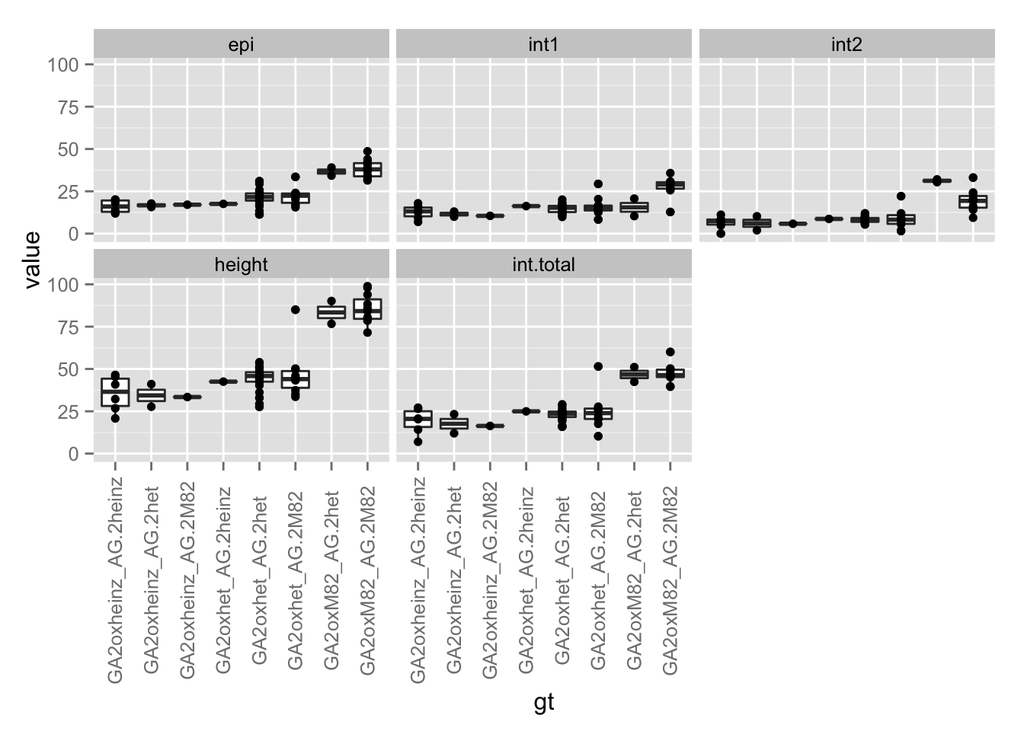

```r
library(ggplot2)
pl <- ggplot(na.omit(tie1.melt),aes(x=gt,y=value))
pl <- pl + geom_boxplot()
pl <- pl + facet_wrap( ~ organ)
pl <- pl + theme(axis.text.x  = element_text(angle=90, vjust=0.5))
pl + geom_point()
```

## test it for epicotyl

### GA2oxidase only

```r
lm1 <- lm(epi ~ GA2,data=tie1)
summary(lm1)
```

```
##
## Call:
## lm(formula = epi ~ GA2, data = tie1)
##
## Residuals:
##      Min       1Q   Median       3Q      Max
## -10.0669  -3.7254   0.3131   2.5931  12.1131
##
## Coefficients:
##             Estimate Std. Error t value Pr(>|t|)
## (Intercept)   16.366      1.548   10.57 9.29e-15 ***
## GA2het         5.051      1.736    2.91  0.00525 **
## GA2M82        21.630      2.014   10.74 5.18e-15 ***
## ---
## Signif. codes:  0 '***' 0.001 '**' 0.01 '*' 0.05 '.' 0.1 ' ' 1
##
## Residual standard error: 4.645 on 54 degrees of freedom
##   (2 observations deleted due to missingness)
## Multiple R-squared:  0.7388, Adjusted R-squared:  0.7291
## F-statistic: 76.36 on 2 and 54 DF,  p-value: < 2.2e-16
```

Very strong effect and we can see the het effect also.

### Alpha-glucosidase only

```r
lm2 <- lm(epi ~ AG,data=tie1)
summary(lm2)
```

```
##
## Call:
## lm(formula = epi ~ AG, data = tie1)
##
## Residuals:
##      Min       1Q   Median       3Q      Max
## -13.7696  -5.5696  -0.1081   3.8591  19.3904
##
## Coefficients:
##             Estimate Std. Error t value Pr(>|t|)
## (Intercept)   16.326      3.023   5.401 1.59e-06 ***
## AGhet          5.702      3.405   1.675 0.099917 .
## AGM82         12.934      3.452   3.747 0.000444 ***
## ---
## Signif. codes:  0 '***' 0.001 '**' 0.01 '*' 0.05 '.' 0.1 ' ' 1
##
## Residual standard error: 7.997 on 53 degrees of freedom
##   (3 observations deleted due to missingness)
## Multiple R-squared:  0.2525, Adjusted R-squared:  0.2243
## F-statistic: 8.952 on 2 and 53 DF,  p-value: 0.0004473
```

Yes there is an effect here but probably due to linkage with GA2ox. Test via additive model.

### Additive model

```r
lm3 <- lm(epi ~ GA2 + AG,data=tie1)
summary(lm3)
```

```
##
## Call:
## lm(formula = epi ~ GA2 + AG, data = tie1)
##
## Residuals:
##     Min      1Q  Median      3Q     Max
## -9.7312 -3.0787  0.3688  2.2787 11.5445
##
## Coefficients:
##             Estimate Std. Error t value Pr(>|t|)
## (Intercept)   15.777      1.841   8.571 2.20e-11 ***
## GA2het         3.840      2.517   1.525    0.133
## GA2M82        19.989      2.892   6.912 8.25e-09 ***
## AGhet          1.464      2.819   0.519    0.606
## AGM82          2.368      2.967   0.798    0.429
## ---
## Signif. codes:  0 '***' 0.001 '**' 0.01 '*' 0.05 '.' 0.1 ' ' 1
##
## Residual standard error: 4.776 on 50 degrees of freedom
##   (4 observations deleted due to missingness)
## Multiple R-squared:  0.744,  Adjusted R-squared:  0.7236
## F-statistic: 36.33 on 4 and 50 DF,  p-value: 3.14e-14
```

This confirms that when both loci are in the model that only GA2 genotype matters

### interaction model

To test whether or not there is some wierd interaction between loci

```r
lm4 <- lm(epi ~ GA2*AG,data=tie1)
summary(lm4)
```

```
##
## Call:
## lm(formula = epi ~ GA2 * AG, data = tie1)
##
## Residuals:
##     Min      1Q  Median      3Q     Max
## -9.8282 -2.9650  0.2718  2.2700 11.5520
##
## Coefficients: (1 not defined because of singularities)
##              Estimate Std. Error t value Pr(>|t|)
## (Intercept)    16.120      2.005   8.042  2.2e-10 ***
## GA2het          1.440      5.303   0.272  0.78717
## GA2M82         21.158      5.128   4.126  0.00015 ***
## AGhet           0.625      4.009   0.156  0.87678
## AGM82           0.960      5.303   0.181  0.85713
## GA2het:AGhet    2.993      6.425   0.466  0.64344
## GA2M82:AGhet   -1.243      7.100  -0.175  0.86175
## GA2het:AGM82    3.458      7.392   0.468  0.64209
## GA2M82:AGM82       NA         NA      NA       NA
## ---
## Signif. codes:  0 '***' 0.001 '**' 0.01 '*' 0.05 '.' 0.1 ' ' 1
##
## Residual standard error: 4.91 on 47 degrees of freedom
##   (4 observations deleted due to missingness)
## Multiple R-squared:  0.7457, Adjusted R-squared:  0.7079
## F-statistic: 19.69 on 7 and 47 DF,  p-value: 5.07e-12
```

Still no evidence for alpha-glucosidase playing a role.

### an alternative

Predict on two-locus genotype

```r
lm5 <- lm(epi ~ gt,data=na.omit(tie1))
summary(lm5)
```

```
##
## Call:
## lm(formula = epi ~ gt, data = na.omit(tie1))
##
## Residuals:
##     Min      1Q  Median      3Q     Max
## -9.8282 -2.9650  0.2718  2.2700 11.5520
##
## Coefficients:
##                      Estimate Std. Error t value Pr(>|t|)
## (Intercept)            16.120      2.005   8.042 2.20e-10 ***
## gtGA2oxheinz_AG.2het    0.625      4.009   0.156   0.8768
## gtGA2oxheinz_AG.2M82    0.960      5.303   0.181   0.8571
## gtGA2oxhet_AG.2heinz    1.440      5.303   0.272   0.7872
## gtGA2oxhet_AG.2het      5.058      2.261   2.237   0.0301 *
## gtGA2oxhet_AG.2M82      5.858      2.535   2.310   0.0253 *
## gtGA2oxM82_AG.2het     20.540      4.009   5.124 5.53e-06 ***
## gtGA2oxM82_AG.2M82     22.118      2.492   8.876 1.30e-11 ***
## ---
## Signif. codes:  0 '***' 0.001 '**' 0.01 '*' 0.05 '.' 0.1 ' ' 1
##
## Residual standard error: 4.91 on 47 degrees of freedom
## Multiple R-squared:  0.7457, Adjusted R-squared:  0.7079
## F-statistic: 19.69 on 7 and 47 DF,  p-value: 5.07e-12
```

## test for total height

### GA2oxidase only

```r
lm1 <- lm(height ~ GA2,data=tie1)
summary(lm1)
```

```
##
## Call:
## lm(formula = height ~ GA2, data = tie1)
##
## Residuals:
##     Min      1Q  Median      3Q     Max
## -17.618  -5.461  -0.178   4.642  39.792
##
## Coefficients:
##             Estimate Std. Error t value Pr(>|t|)
## (Intercept)   34.961      3.065  11.407 5.28e-16 ***
## GA2het        10.257      3.436   2.985  0.00426 **
## GA2M82        50.130      3.987  12.573  < 2e-16 ***
## ---
## Signif. codes:  0 '***' 0.001 '**' 0.01 '*' 0.05 '.' 0.1 ' ' 1
##
## Residual standard error: 9.195 on 54 degrees of freedom
##   (2 observations deleted due to missingness)
## Multiple R-squared:  0.8015, Adjusted R-squared:  0.7941
## F-statistic:   109 on 2 and 54 DF,  p-value: < 2.2e-16
```

Very strong effect and we can see het effect also.

### Alpha-glucosidase only

```r
lm2 <- lm(height ~ AG,data=tie1)
summary(lm2)
```

```
##
## Call:
## lm(formula = height ~ AG, data = tie1)
##
## Residuals:
##     Min      1Q  Median      3Q     Max
## -31.090 -14.407  -0.187   9.252  43.613
##
## Coefficients:
##             Estimate Std. Error t value Pr(>|t|)
## (Intercept)   36.430      6.774   5.378 1.73e-06 ***
## AGhet         10.107      7.632   1.324 0.191081
## AGM82         28.070      7.736   3.628 0.000642 ***
## ---
## Signif. codes:  0 '***' 0.001 '**' 0.01 '*' 0.05 '.' 0.1 ' ' 1
##
## Residual standard error: 17.92 on 53 degrees of freedom
##   (3 observations deleted due to missingness)
## Multiple R-squared:  0.262,  Adjusted R-squared:  0.2341
## F-statistic: 9.407 on 2 and 53 DF,  p-value: 0.000319
```

Yes there is an effect here but probably due to linkage with GA2ox. Test via additive model.

### Additive model

```r
lm3 <- lm(height ~ GA2 + AG,data=tie1)
summary(lm3)
```

```
##
## Call:
## lm(formula = height ~ GA2 + AG, data = tie1)
##
## Residuals:
##     Min      1Q  Median      3Q     Max
## -16.722  -5.806  -0.002   4.583  38.506
##
## Coefficients:
##             Estimate Std. Error t value Pr(>|t|)
## (Intercept)   34.983      3.653   9.576 6.77e-13 ***
## GA2het        10.131      4.996   2.028   0.0479 *
## GA2M82        49.054      5.740   8.546 2.41e-11 ***
## AGhet         -0.792      5.594  -0.142   0.8880
## AGM82          1.390      5.888   0.236   0.8144
## ---
## Signif. codes:  0 '***' 0.001 '**' 0.01 '*' 0.05 '.' 0.1 ' ' 1
##
## Residual standard error: 9.479 on 50 degrees of freedom
##   (4 observations deleted due to missingness)
## Multiple R-squared:  0.8043, Adjusted R-squared:  0.7887
## F-statistic: 51.38 on 4 and 50 DF,  p-value: < 2.2e-16
```

This confirms that when both loci are in the model that only GA2 genotype matters

### interaction model

To test whether or not there is some wierd interaction between loci

```r
lm4 <- lm(height ~ GA2*AG,data=tie1)
summary(lm4)
```

```
##
## Call:
## lm(formula = height ~ GA2 * AG, data = tie1)
##
## Residuals:
##     Min      1Q  Median      3Q     Max
## -16.690  -5.776   0.030   4.611  38.177
##
## Coefficients: (1 not defined because of singularities)
##              Estimate Std. Error t value Pr(>|t|)
## (Intercept)    35.417      3.983   8.891 1.23e-11 ***
## GA2het          7.093     10.539   0.673    0.504
## GA2M82         51.986     10.191   5.101 5.97e-06 ***
## AGhet          -1.047      7.967  -0.131    0.896
## AGM82          -2.007     10.539  -0.190    0.850
## GA2het:AGhet    2.827     12.767   0.221    0.826
## GA2M82:AGhet   -2.946     14.109  -0.209    0.835
## GA2het:AGM82    6.330     14.690   0.431    0.669
## GA2M82:AGM82       NA         NA      NA       NA
## ---
## Signif. codes:  0 '***' 0.001 '**' 0.01 '*' 0.05 '.' 0.1 ' ' 1
##
## Residual standard error: 9.757 on 47 degrees of freedom
##   (4 observations deleted due to missingness)
## Multiple R-squared:  0.8051, Adjusted R-squared:  0.7761
## F-statistic: 27.74 on 7 and 47 DF,  p-value: 1.173e-14
```

### an alternative

Predicted on two-locus genotype

```r
lm5 <- lm(height ~ gt,data=na.omit(tie1))
summary(lm5)
```

```
##
## Call:
## lm(formula = height ~ gt, data = na.omit(tie1))
##
## Residuals:
##     Min      1Q  Median      3Q     Max
## -16.690  -5.776   0.030   4.611  38.177
##
## Coefficients:
##                      Estimate Std. Error t value Pr(>|t|)
## (Intercept)            35.417      3.983   8.891 1.23e-11 ***
## gtGA2oxheinz_AG.2het   -1.047      7.967  -0.131   0.8960
## gtGA2oxheinz_AG.2M82   -2.007     10.539  -0.190   0.8498
## gtGA2oxhet_AG.2heinz    7.093     10.539   0.673   0.5042
## gtGA2oxhet_AG.2het      8.874      4.494   1.975   0.0542 .
## gtGA2oxhet_AG.2M82     11.416      5.039   2.266   0.0281 *
## gtGA2oxM82_AG.2het     47.993      7.967   6.024 2.48e-07 ***
## gtGA2oxM82_AG.2M82     49.980      4.952  10.093 2.38e-13 ***
## ---
## Signif. codes:  0 '***' 0.001 '**' 0.01 '*' 0.05 '.' 0.1 ' ' 1
##
## Residual standard error: 9.757 on 47 degrees of freedom
## Multiple R-squared:  0.8051, Adjusted R-squared:  0.7761
## F-statistic: 27.74 on 7 and 47 DF,  p-value: 1.173e-14
```

## test for total internode

### GA2oxidase only

```r
lm1 <- lm(int.total ~ GA2,data=tie1)
summary(lm1)
```

```
##
## Call:
## lm(formula = int.total ~ GA2, data = tie1)
##
## Residuals:
##      Min       1Q   Median       3Q      Max
## -13.5314  -2.7014   0.0586   2.0986  27.6786
##
## Coefficients:
##             Estimate Std. Error t value Pr(>|t|)
## (Intercept)   18.596      2.039   9.122 1.59e-12 ***
## GA2het         5.206      2.286   2.278   0.0267 *
## GA2M82        28.500      2.652  10.747 5.02e-15 ***
## ---
## Signif. codes:  0 '***' 0.001 '**' 0.01 '*' 0.05 '.' 0.1 ' ' 1
##
## Residual standard error: 6.116 on 54 degrees of freedom
##   (2 observations deleted due to missingness)
## Multiple R-squared:  0.7527, Adjusted R-squared:  0.7436
## F-statistic:  82.2 on 2 and 54 DF,  p-value: < 2.2e-16
```

Very strong effect and we can see het effect also.

### Alpha-glucosidase only

```r
lm2 <- lm(int.total ~ AG,data=tie1)
summary(lm2)
```

```
##
## Call:
## lm(formula = int.total ~ AG, data = tie1)
##
## Residuals:
##      Min       1Q   Median       3Q      Max
## -24.9704  -7.7049  -0.5685   5.2257  26.5915
##
## Coefficients:
##             Estimate Std. Error t value Pr(>|t|)
## (Intercept)   20.104      4.086   4.920  8.8e-06 ***
## AGhet          4.404      4.604   0.957  0.34307
## AGM82         15.136      4.667   3.243  0.00205 **
## ---
## Signif. codes:  0 '***' 0.001 '**' 0.01 '*' 0.05 '.' 0.1 ' ' 1
##
## Residual standard error: 10.81 on 53 degrees of freedom
##   (3 observations deleted due to missingness)
## Multiple R-squared:  0.2396, Adjusted R-squared:  0.2109
## F-statistic: 8.349 on 2 and 53 DF,  p-value: 0.0007048
```

Yes there is an effect here but probably due to linkage with GA2ox. Test via additive model.

### Additive model

```r
lm3 <- lm(int.total ~ GA2 + AG,data=tie1)
summary(lm3)
```

```
##
## Call:
## lm(formula = int.total ~ GA2 + AG, data = tie1)
##
## Residuals:
##      Min       1Q   Median       3Q      Max
## -14.2481  -2.8993   0.1095   2.0238  26.9619
##
## Coefficients:
##             Estimate Std. Error t value Pr(>|t|)
## (Intercept)  19.2056     2.4252   7.919 2.22e-10 ***
## GA2het        6.2909     3.3168   1.897   0.0637 .
## GA2M82       29.0647     3.8106   7.627 6.30e-10 ***
## AGhet        -2.2560     3.7138  -0.607   0.5463
## AGM82        -0.9784     3.9090  -0.250   0.8034
## ---
## Signif. codes:  0 '***' 0.001 '**' 0.01 '*' 0.05 '.' 0.1 ' ' 1
##
## Residual standard error: 6.293 on 50 degrees of freedom
##   (4 observations deleted due to missingness)
## Multiple R-squared:  0.7569, Adjusted R-squared:  0.7374
## F-statistic: 38.91 on 4 and 50 DF,  p-value: 8.811e-15
```

This confirms that when both loci are in the model that only GA2 genotype matters

### interaction model

To test whether or not there is some wierd interaction between loci

```r
lm4 <- lm(int.total ~ GA2*AG,data=tie1)
summary(lm4)
```

```
##
## Call:
## lm(formula = int.total ~ GA2 * AG, data = tie1)
##
## Residuals:
##      Min       1Q   Median       3Q      Max
## -14.5850  -3.0036   0.2377   1.9734  26.6250
##
## Coefficients: (1 not defined because of singularities)
##              Estimate Std. Error t value Pr(>|t|)
## (Intercept)   19.2967     2.6447   7.296 2.91e-09 ***
## GA2het         5.6533     6.9972   0.808    0.423
## GA2M82        30.8282     6.7662   4.556 3.71e-05 ***
## AGhet         -1.6717     5.2894  -0.316    0.753
## AGM82         -2.9667     6.9972  -0.424    0.674
## GA2het:AGhet  -0.1661     8.4765  -0.020    0.984
## GA2M82:AGhet  -1.7032     9.3674  -0.182    0.857
## GA2het:AGM82   2.8717     9.7532   0.294    0.770
## GA2M82:AGM82       NA         NA      NA       NA
## ---
## Signif. codes:  0 '***' 0.001 '**' 0.01 '*' 0.05 '.' 0.1 ' ' 1
##
## Residual standard error: 6.478 on 47 degrees of freedom
##   (4 observations deleted due to missingness)
## Multiple R-squared:  0.7578, Adjusted R-squared:  0.7217
## F-statistic: 21.01 on 7 and 47 DF,  p-value: 1.676e-12
```

```r
lm5 <- lm(int.total ~ gt,data=na.omit(tie1))
summary(lm5)
```

```
##
## Call:
## lm(formula = int.total ~ gt, data = na.omit(tie1))
##
## Residuals:
##      Min       1Q   Median       3Q      Max
## -14.5850  -3.0036   0.2377   1.9734  26.6250
##
## Coefficients:
##                      Estimate Std. Error t value Pr(>|t|)
## (Intercept)            19.297      2.645   7.296 2.91e-09 ***
## gtGA2oxheinz_AG.2het   -1.672      5.289  -0.316    0.753
## gtGA2oxheinz_AG.2M82   -2.967      6.997  -0.424    0.674
## gtGA2oxhet_AG.2heinz    5.653      6.997   0.808    0.423
## gtGA2oxhet_AG.2het      3.816      2.984   1.279    0.207
## gtGA2oxhet_AG.2M82      5.558      3.345   1.662    0.103
## gtGA2oxM82_AG.2het     27.453      5.289   5.190 4.41e-06 ***
## gtGA2oxM82_AG.2M82     27.862      3.288   8.474 5.04e-11 ***
## ---
## Signif. codes:  0 '***' 0.001 '**' 0.01 '*' 0.05 '.' 0.1 ' ' 1
##
## Residual standard error: 6.478 on 47 degrees of freedom
## Multiple R-squared:  0.7578, Adjusted R-squared:  0.7217
## F-statistic: 21.01 on 7 and 47 DF,  p-value: 1.676e-12
```

### make a figure

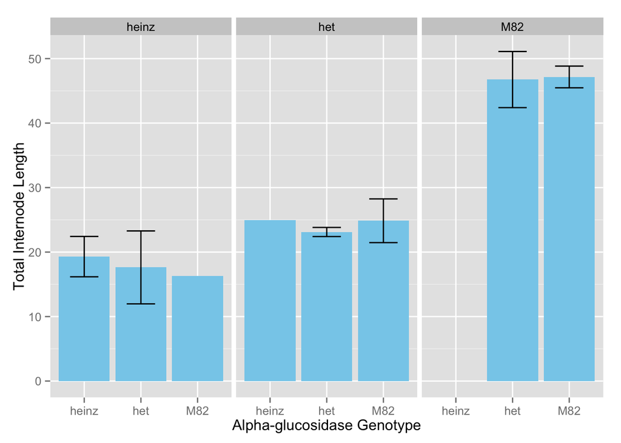

```r
#make a function for summarizing
mean.sem <- function(x,na.rm=TRUE) {
  if(na.rm) x <- na.omit(x)
  mean.x <- mean(x)
  sem.x <- sd(x)/sqrt(length(x))
  data.frame(
    y=mean.x,
    ymin=mean.x-sem.x,
    ymax=mean.x+sem.x)
}

#plot AG conditioned on GA2
pl <- ggplot(data=na.omit(tie1),aes(x=AG,y=int.total))
pl <- pl + geom_bar(stat="summary",fun.data="mean.sem",fill="skyblue")
pl <- pl + geom_errorbar(stat="summary",fun.data="mean.sem",width=0.5)
pl <- pl + facet_wrap( ~ GA2,nrow=1)
pl + ylab("Total Internode Length") + xlab("Alpha-glucosidase Genotype")
```

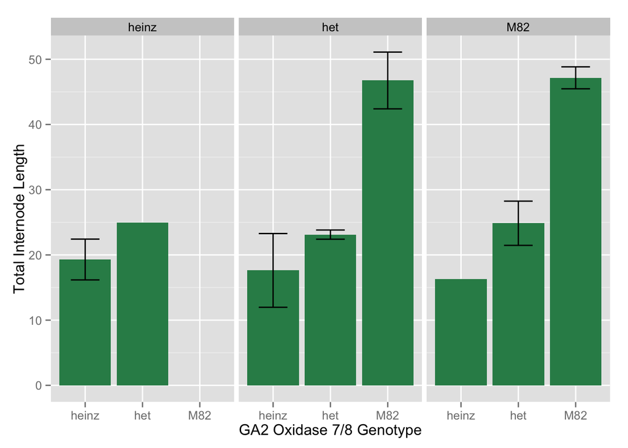

```r
ggsave("AG2_total_internode.pdf",height=6,width=6)

#plot GA2 conditions on AG
pl <- ggplot(data=na.omit(tie1),aes(x=GA2,y=int.total))
pl <- pl + geom_bar(stat="summary",fun.data="mean.sem",fill="seagreen")
pl <- pl + geom_errorbar(stat="summary",fun.data="mean.sem",width=0.5)
pl <- pl + facet_wrap( ~ AG,nrow=1)
pl + ylab("Total Internode Length") + xlab("GA2 Oxidase 7/8 Genotype")
```

```r
ggsave("GA2_total_internode.pdf",height=6,width=6)
```